# Functional Data Analysis of EEG Data Comparing Alcoholics & Controls

Aoife O’Brien & Alannah Blacoe

## Objective

- Investigate EEG correlates of genetic predisposition to alcoholism
- Use Functional Data Analysis (FDA) to compare alcoholic vs control EEG patterns
- Explore clustering and prediction of group membership from EEG curves

## Background & Motivation

- EEG produces hundreds of measurements per second.
- Traditional stats simplify this to averages — losing shape.
- FDA treats EEG as **curves over time**.
- FPCA extracts dominant patterns from these curves.

## The Dataset

- **Subjects:** Alcoholic & Control groups
- **Electrodes:** 64 scalp sites (256 Hz sampling)
- **Focus:** FP1 and FP2 frontal electrodes
- **Stimuli:**
  - S1 Object (single image)
  - S2 Match (same second image)
  - S2 Non-match (different second image)

## Research Questions

1. Do alcoholic and control participants show different EEG response patterns?
2. How do visual stimuli impact EEG curves?
3. Can we group participants based on EEG shape using clustering?
4. Can we predict group membership from EEG data?

## Why Functional Data?

- EEG curves are not points — they’re shapes.
- FDA handles entire time-dependent signal
- FPCA captures shared shapes across participants

## Raw EEG Curve from FP1

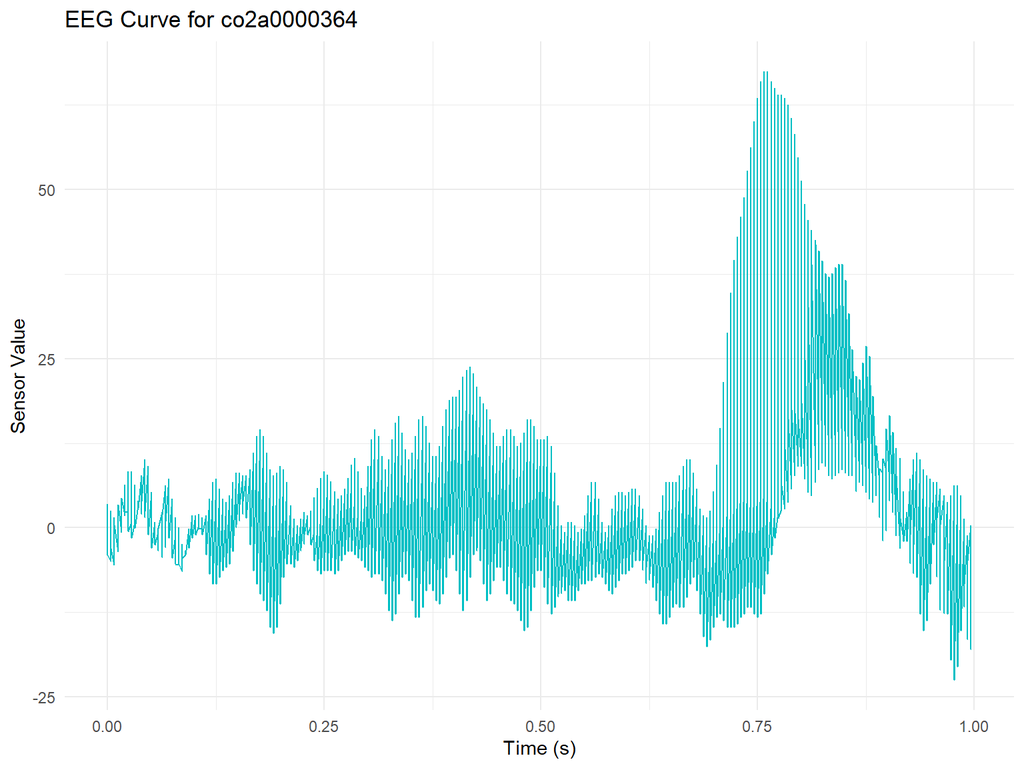

## Permutation Test

- A **non-parametric test** used to compare groups
- Shuffles group labels (e.g., alcoholic vs control) many times
- Builds a **null distribution** of test statistics
- Compares actual observed stat to that distribution
- No assumptions about normality — perfect for complex data like EEG

## FP1 Electrode (S2 Non-match)

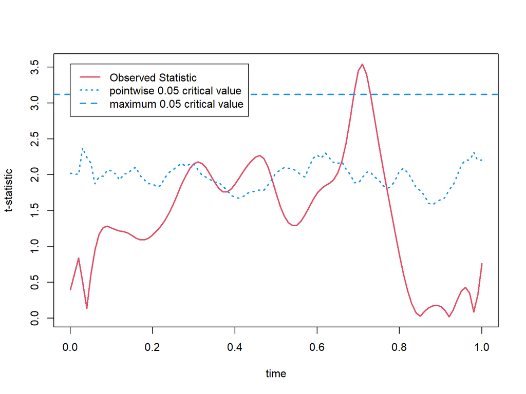

## FPCA Model

$$X(t) = \mu(t) + \sum_{k=1}^{K} \xi_k \phi_k(t)$$

- $\mu(t)$: mean EEG curve
- $\phi_k(t)$: principal components (shapes)
- $\xi_k$: subject-level scores

## FPCA Summary – FP1

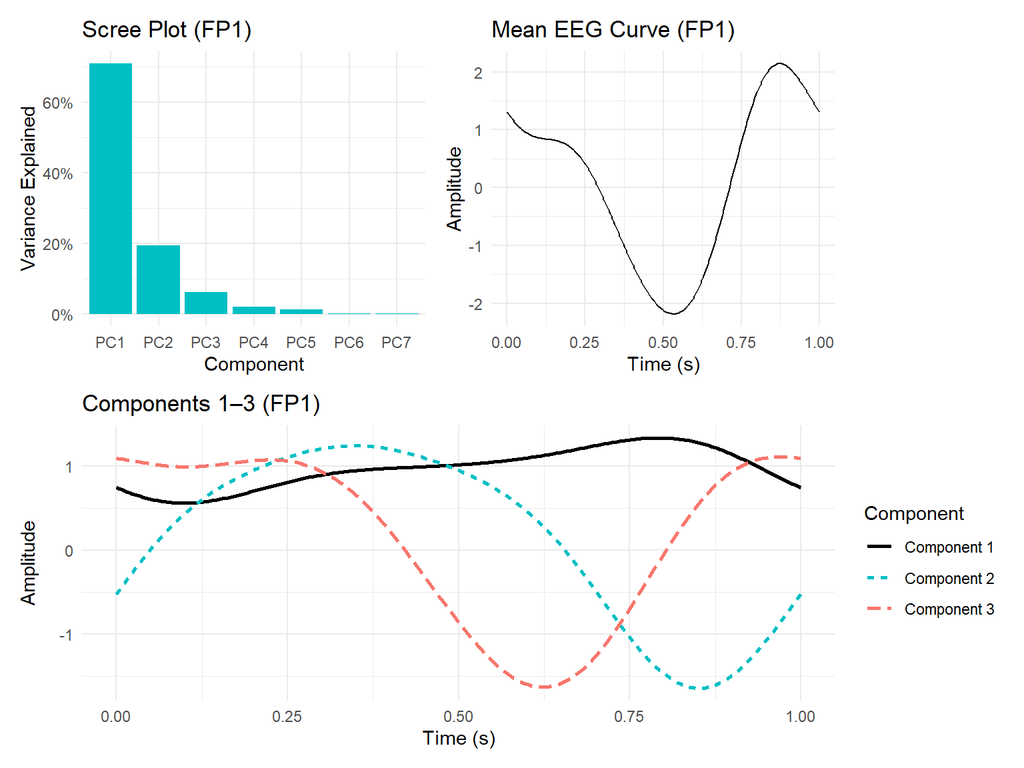

## RQ1: Do EEG Patterns Differ by Group?

- Permutation test showed significant group differences
- Strongest for **non-matching stimuli** (S2 Non-match)

## RQ2: Effect of Stimuli on EEG

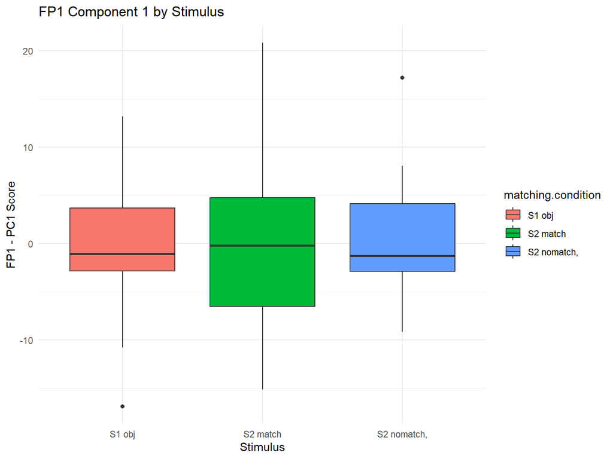

## RQ3: Clustering on EEG Shape

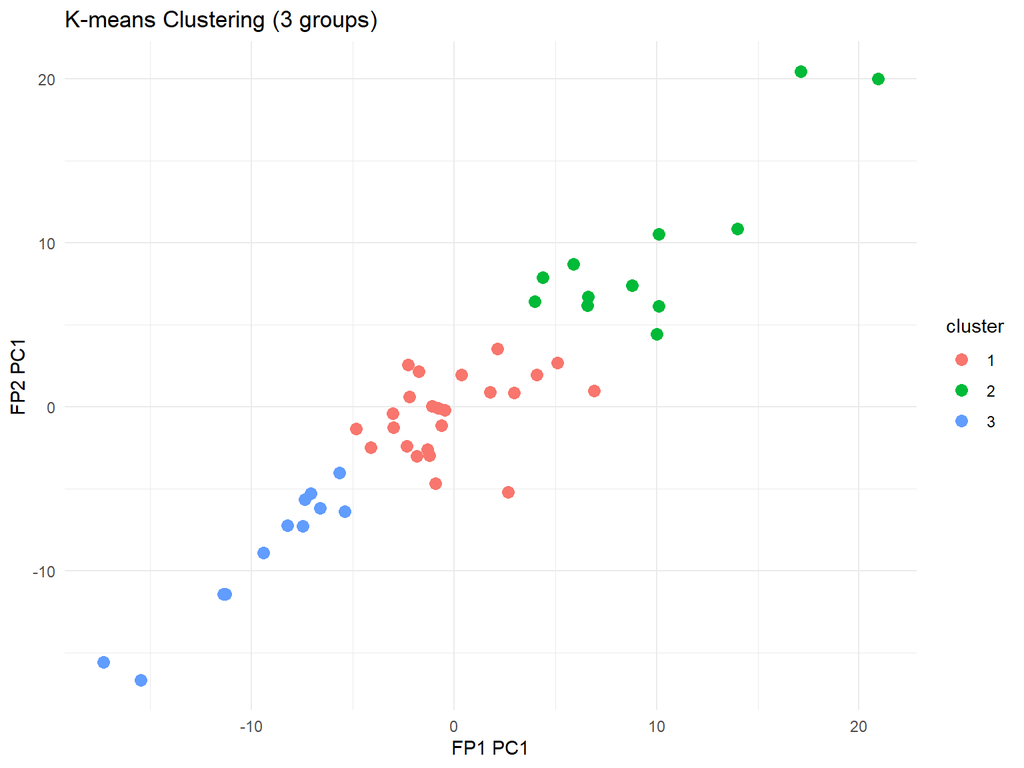

## RQ4: Can We Predict Group from EEG?

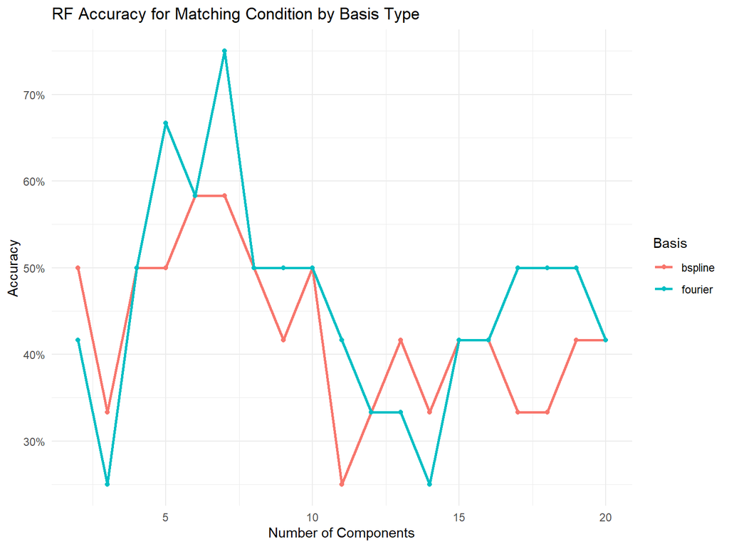

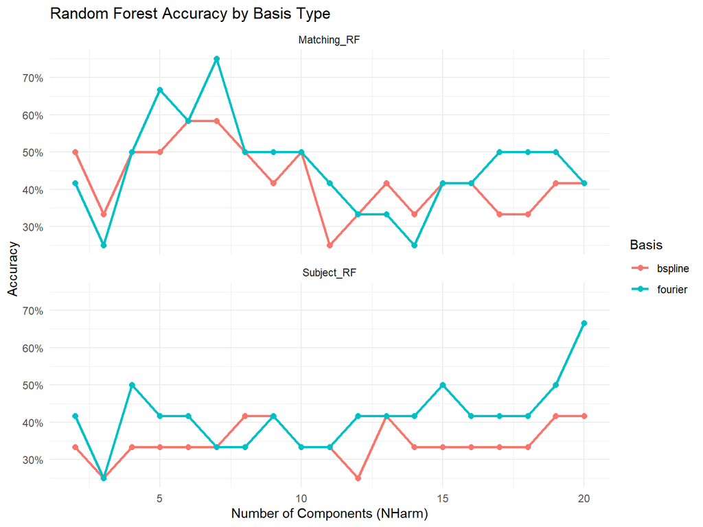

## Component Tuning Results

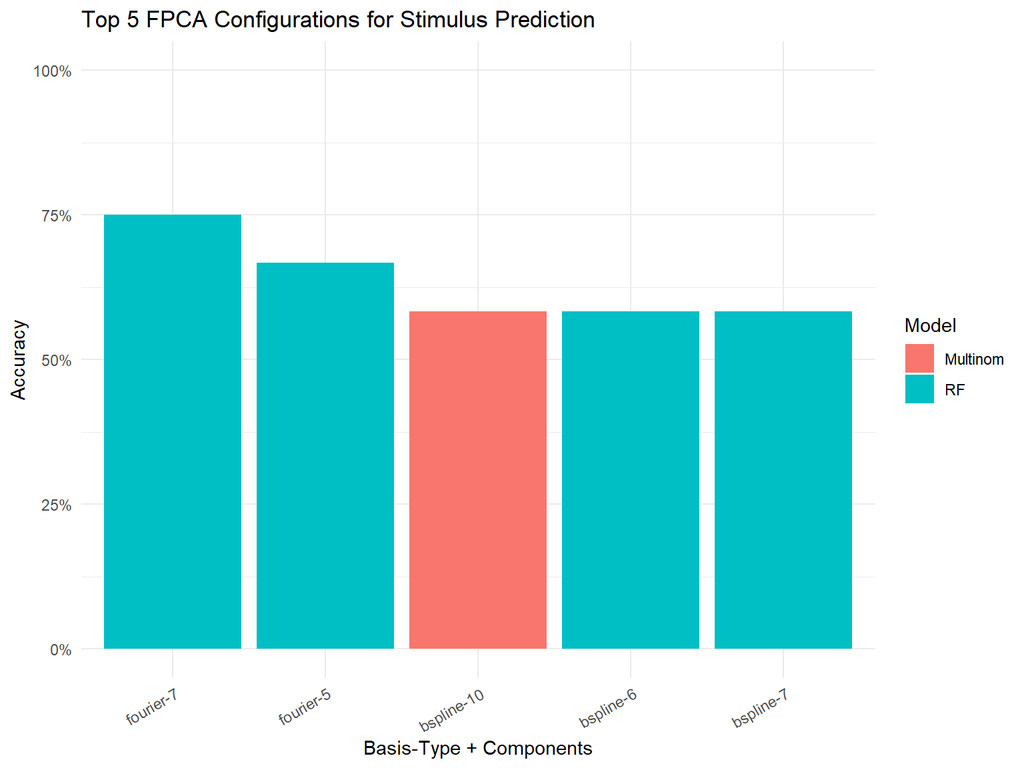

## Limitations

- Small sample size (only 16 subjects)
- Limited to FP1 and FP2 sensors
- Only the first trial per condition included
- Possible subject-level confounding not accounted for

## Clustering and modelling may overfit due to high dimensionality

## Conclusion & Next Steps

**Next Steps** - Extend to all 64 electrodes - Explore time-locked responses (e.g., ERP) - Try deep learning models (e.g., CNN)